# Biomarker discovery

Gayathri Jonnalagadda

2024-02-12

This practical is designed to get equipped with the process of using tets like PCA with biological data “Working with omics data to tackle a biological question” The data used in the practical is of glioblastoma patients, expression and meta data

```r
#Reading the data for key visualisations
exp_data<- read.csv('M:\\Documents\\Gexpdata.csv', header = TRUE, row.names = 1)
#let us look at the data
head(exp_data)
```

```
##         TCGA.02.0003.01A.01 TCGA.02.0010.01A.01 TCGA.02.0011.01B.01
## CDKN1B               1.2510              0.8127              2.0990
## EPB41                0.2168              2.5160              1.7220
## CLGN                 2.3440              3.8050              3.0050
## PDE10A               1.2110              2.9300              3.1340
## RALGPS2              0.8402              1.2750              1.7260
## TAF5                 0.9178              2.1940              0.1435
##         TCGA.02.0014.01A.01 TCGA.02.0024.01B.01 TCGA.02.0026.01B.01
## CDKN1B               0.2565               1.495            -0.06608
## EPB41                2.3110               1.466             2.43300
## CLGN                 3.4780               1.774             3.50900
## PDE10A               2.0200               2.922             2.60300
## RALGPS2              1.3370               1.759             1.21700
## TAF5                 2.6240               1.797             2.91800
##         TCGA.02.0028.01A.01 TCGA.02.0046.01A.01 TCGA.02.0047.01A.01
## CDKN1B               1.2770              1.7270              0.9559
## EPB41               -0.1037              0.1324              0.3143
## CLGN                 1.6590              0.9656              1.9000
## PDE10A               1.9680              1.8410              1.8070
## RALGPS2              0.7874             -0.2749              0.7758
## TAF5                 2.8840              1.1520              1.3500
##         TCGA.02.0048.01A.01 TCGA.02.0060.01A.01 TCGA.02.0069.01A.01
## CDKN1B               1.5850            1.236000              0.3182
## EPB41                0.0321           -0.399000              1.4250
## CLGN                 2.8730            3.299000             -1.3880
## PDE10A               2.6230            0.009474             -0.7013
## RALGPS2             -0.1512            1.341000              1.4410
## TAF5                 0.3125            1.671000              2.2560
##         TCGA.02.0074.01A.01 TCGA.02.0080.01A.01 TCGA.02.0084.01A.03
## CDKN1B               0.5996              1.1850            0.398400
## EPB41                1.0090              0.2046           -0.035510
## CLGN                 2.9850              1.6220           -0.004141
## PDE10A               1.9130             -0.2581            0.645800
## RALGPS2              1.5520              1.1900            0.577000
## TAF5                 0.6579              0.1677           -0.585100
##         TCGA.02.0087.01A.01 TCGA.02.0104.01A.01 TCGA.02.0114.01A.01
## CDKN1B             -0.02551              0.8950              1.1200
## EPB41               1.13800              1.7550              0.8486
## CLGN               -0.47860              4.0190             -0.5702
## PDE10A              0.27090              1.5860              3.4670
```

[output cut: 288 more lines]

```
## TAF5               -1.27800            -0.59290             -0.6518
##         TCGA.08.0509.01A.01 TCGA.08.0510.01A.01 TCGA.08.0512.01A.01
## CDKN1B              -0.5221             -1.5570             -0.5034
## EPB41                0.2289              0.9025              0.1162
## CLGN                -1.0100             -0.1448              2.8460
## PDE10A              -0.4437             -2.1430             -0.4603
## RALGPS2             -0.4521             -1.0850             -0.3201
## TAF5                -0.7586             -0.4408              0.1954
##         TCGA.08.0522.01A.01 TCGA.12.0619.01A.01 TCGA.12.0620.01A.01
## CDKN1B              -1.3600             -0.3294             -0.1153
## EPB41               -0.6491              2.0620             -1.2070
## CLGN                 1.9990              3.5340             -0.9831
## PDE10A              -0.4582              1.4860             -0.2174
## RALGPS2             -0.5923             -0.6235             -0.5758
## TAF5                 0.6023              0.6332             -0.8239
```

```r
#head() is used to display the first  few rows of an   #object; to get a quick overview of the data
```

The above expression data contains samples as columns and genes, expressions or metabolites as rows. Each sample may represent idividual patient. “let us try anither function called dim()that tells us dimensions of the specified matrix, array or data frame”

```r
dim(exp_data)
```

```
## [1] 840 147
```

```r
#Loading the meta data file
meta_data<- read.csv('M:\\Documents\\Gmeta_data.csv', header = TRUE)
# ovrview of the data
head(meta_data)
```

```
##             PatientID     Class
## 1 TCGA.02.0003.01A.01 Proneural
## 2 TCGA.02.0010.01A.01 Proneural
## 3 TCGA.02.0011.01B.01 Proneural
## 4 TCGA.02.0014.01A.01 Proneural
## 5 TCGA.02.0024.01B.01 Proneural
## 6 TCGA.02.0026.01B.01 Proneural
```

“To perform multivariate test like PCA we are going to require the above expression data transposed so that the samples are rows and genes, variables et are columns” “PCA: PCA is a technique that simplifies complex data by finding the most important patterns and reducing the number of features. 📊”

```r
#Let us plot PCA
pcaresults<- prcomp(t(exp_data))
#lets look at the summary of the pca results
summary(pcaresults)
```

```
## Importance of components:
##                           PC1     PC2     PC3     PC4     PC5     PC6     PC7
## Standard deviation     22.463 16.2478 7.77359 6.49987 5.88777 5.71774 4.83235
## Proportion of Variance  0.352  0.1842 0.04215 0.02947 0.02418 0.02281 0.01629
## Cumulative Proportion   0.352  0.5362 0.57831 0.60778 0.63196 0.65477 0.67106
##                            PC8     PC9    PC10    PC11    PC12    PC13    PC14
## Standard deviation     4.61243 4.44279 4.12759 3.95647 3.81915 3.74186 3.63888
## Proportion of Variance 0.01484 0.01377 0.01188 0.01092 0.01017 0.00977 0.00924
## Cumulative Proportion  0.68590 0.69967 0.71155 0.72247 0.73264 0.74241 0.75165
##                           PC15   PC16    PC17    PC18    PC19    PC20   PC21
## Standard deviation     3.43379 3.2999 3.21741 3.14798 2.98413 2.91243 2.8843
## Proportion of Variance 0.00823 0.0076 0.00722 0.00691 0.00621 0.00592 0.0058
## Cumulative Proportion  0.75987 0.7675 0.77469 0.78160 0.78782 0.79373 0.7995
##                          PC22    PC23    PC24    PC25    PC26    PC27    PC28
## Standard deviation     2.8592 2.79494 2.69157 2.66013 2.59294 2.54818 2.50998
## Proportion of Variance 0.0057 0.00545 0.00505 0.00494 0.00469 0.00453 0.00439
## Cumulative Proportion  0.8052 0.81069 0.81574 0.82068 0.82537 0.82990 0.83429
##                           PC29    PC30    PC31    PC32    PC33    PC34    PC35
## Standard deviation     2.44014 2.42151 2.37296 2.33655 2.29337 2.23209 2.21075
## Proportion of Variance 0.00415 0.00409 0.00393 0.00381 0.00367 0.00348 0.00341
## Cumulative Proportion  0.83845 0.84254 0.84646 0.85027 0.85394 0.85742 0.86083
##                           PC36    PC37    PC38    PC39    PC40    PC41    PC42
## Standard deviation     2.19341 2.16180 2.12792 2.12745 2.08961 2.06275 2.02695
## Proportion of Variance 0.00336 0.00326 0.00316 0.00316 0.00305 0.00297 0.00287
## Cumulative Proportion  0.86418 0.86744 0.87060 0.87376 0.87680 0.87977 0.88264
##                           PC43    PC44    PC45    PC46    PC47    PC48    PC49
## Standard deviation     2.00765 1.98322 1.94475 1.92658 1.90644 1.86934 1.86319
## Proportion of Variance 0.00281 0.00274 0.00264 0.00259 0.00254 0.00244 0.00242
## Cumulative Proportion  0.88545 0.88819 0.89083 0.89342 0.89596 0.89839 0.90082
##                           PC50    PC51    PC52    PC53    PC54    PC55   PC56
## Standard deviation     1.84999 1.81128 1.80348 1.78076 1.76518 1.75336 1.7365
## Proportion of Variance 0.00239 0.00229 0.00227 0.00221 0.00217 0.00214 0.0021
## Cumulative Proportion  0.90320 0.90549 0.90776 0.90997 0.91215 0.91429 0.9164
##                           PC57    PC58    PC59    PC60   PC61    PC62    PC63
## Standard deviation     1.71582 1.69876 1.68440 1.66746 1.6486 1.61654 1.60118
## Proportion of Variance 0.00205 0.00201 0.00198 0.00194 0.0019 0.00182 0.00179
## Cumulative Proportion  0.91845 0.92046 0.92244 0.92438 0.9263 0.92810 0.92989
##                           PC64    PC65    PC66    PC67    PC68    PC69    PC70
## Standard deviation     1.58484 1.57554 1.56589 1.54137 1.52462 1.51843 1.49824
## Proportion of Variance 0.00175 0.00173 0.00171 0.00166 0.00162 0.00161 0.00157
```

[output cut: 30 more lines]

```
## Standard deviation     0.89868 0.88370 0.88160 0.86081 0.8499 0.8480 0.83596
## Proportion of Variance 0.00056 0.00054 0.00054 0.00052 0.0005 0.0005 0.00049
## Cumulative Proportion  0.98946 0.99000 0.99055 0.99106 0.9916 0.9921 0.99256
##                          PC127   PC128   PC129   PC130   PC131   PC132   PC133
## Standard deviation     0.82421 0.81031 0.80632 0.79907 0.78460 0.77149 0.77064
## Proportion of Variance 0.00047 0.00046 0.00045 0.00045 0.00043 0.00042 0.00041
## Cumulative Proportion  0.99303 0.99349 0.99394 0.99439 0.99482 0.99523 0.99565
##                          PC134   PC135   PC136   PC137   PC138   PC139   PC140
## Standard deviation     0.76384 0.74326 0.73044 0.72681 0.71998 0.71390 0.70110
## Proportion of Variance 0.00041 0.00039 0.00037 0.00037 0.00036 0.00036 0.00034
## Cumulative Proportion  0.99605 0.99644 0.99681 0.99718 0.99754 0.99790 0.99824
##                          PC141   PC142   PC143  PC144   PC145   PC146     PC147
## Standard deviation     0.68700 0.67175 0.66886 0.6514 0.63979 0.56622 9.976e-15
## Proportion of Variance 0.00033 0.00031 0.00031 0.0003 0.00029 0.00022 0.000e+00
## Cumulative Proportion  0.99857 0.99888 0.99919 0.9995 0.99978 1.00000 1.000e+00
```

```r
perc_accounted<- summary(pcaresults)$importance[2, ] *100
perc_accounted
```

```
##    PC1    PC2    PC3    PC4    PC5    PC6    PC7    PC8    PC9   PC10   PC11
## 35.200 18.415  4.215  2.947  2.418  2.281  1.629  1.484  1.377  1.188  1.092
##   PC12   PC13   PC14   PC15   PC16   PC17   PC18   PC19   PC20   PC21   PC22
##  1.017  0.977  0.924  0.823  0.760  0.722  0.691  0.621  0.592  0.580  0.570
##   PC23   PC24   PC25   PC26   PC27   PC28   PC29   PC30   PC31   PC32   PC33
##  0.545  0.505  0.494  0.469  0.453  0.439  0.415  0.409  0.393  0.381  0.367
##   PC34   PC35   PC36   PC37   PC38   PC39   PC40   PC41   PC42   PC43   PC44
##  0.348  0.341  0.336  0.326  0.316  0.316  0.305  0.297  0.287  0.281  0.274
##   PC45   PC46   PC47   PC48   PC49   PC50   PC51   PC52   PC53   PC54   PC55
##  0.264  0.259  0.254  0.244  0.242  0.239  0.229  0.227  0.221  0.217  0.214
##   PC56   PC57   PC58   PC59   PC60   PC61   PC62   PC63   PC64   PC65   PC66
##  0.210  0.205  0.201  0.198  0.194  0.190  0.182  0.179  0.175  0.173  0.171
##   PC67   PC68   PC69   PC70   PC71   PC72   PC73   PC74   PC75   PC76   PC77
##  0.166  0.162  0.161  0.157  0.152  0.151  0.143  0.141  0.139  0.138  0.134
##   PC78   PC79   PC80   PC81   PC82   PC83   PC84   PC85   PC86   PC87   PC88
##  0.128  0.127  0.124  0.122  0.119  0.117  0.115  0.112  0.111  0.108  0.105
##   PC89   PC90   PC91   PC92   PC93   PC94   PC95   PC96   PC97   PC98   PC99
##  0.103  0.103  0.100  0.098  0.096  0.095  0.092  0.091  0.090  0.089  0.087
##  PC100  PC101  PC102  PC103  PC104  PC105  PC106  PC107  PC108  PC109  PC110
##  0.084  0.083  0.081  0.080  0.079  0.075  0.075  0.073  0.072  0.070  0.069
##  PC111  PC112  PC113  PC114  PC115  PC116  PC117  PC118  PC119  PC120  PC121
##  0.068  0.067  0.065  0.064  0.064  0.062  0.059  0.059  0.058  0.056  0.054
##  PC122  PC123  PC124  PC125  PC126  PC127  PC128  PC129  PC130  PC131  PC132
##  0.054  0.052  0.050  0.050  0.049  0.047  0.046  0.045  0.045  0.043  0.042
##  PC133  PC134  PC135  PC136  PC137  PC138  PC139  PC140  PC141  PC142  PC143
##  0.041  0.041  0.039  0.037  0.037  0.036  0.036  0.034  0.033  0.031  0.031
##  PC144  PC145  PC146  PC147
##  0.030  0.029  0.022  0.000
```

The percentage of variance for each principal component (PC) in PCA tells us how much important information that PC captures from the data. High percentages mean more relevance, while low percentages indicate less impact. It guides decisions on which PCs to keep and simplifies data analysis. Visualizing all the 147 PCA can be overwelhming, lets start with only PCA1 and PCA2 to observe the data grouping.

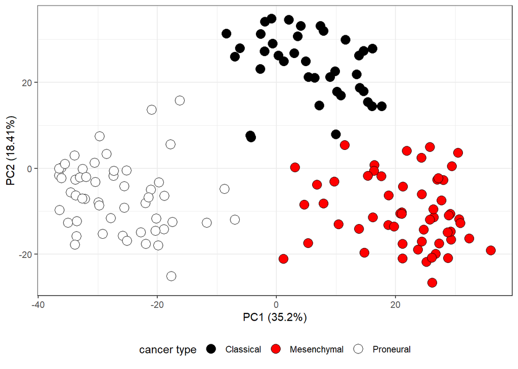

```r
#Let us plot the PCA  reults

library(ggplot2)
ggplot(data=data.frame(pcaresults$x), aes(x=PC1, y=PC2)) +
      geom_point(aes(fill=meta_data$Class),colour="black",size=4,pch=21)+
      scale_fill_manual(values=c("black","red","white"),name="cancer type")+
      xlab(paste("PC1", " (", round(perc_accounted[1],2), "%)", sep=""))+
      ylab(paste("PC2"," (", round(perc_accounted[2],2), "%)", sep=""))+
      theme_bw()+
      theme(legend.position="bottom")
```

we are going to split the data into training and testing values to build a model using random classifier. lets break the data into 20% testing values and 80% training values.

```r
# Set seed for reproducibility
set.seed(800)

# Calculate random 80% of positions within our data per class and store it in a list
indices_training_list <- lapply(unique(meta_data$Class), function(x) {
    n.choose = round(0.8 * sum(meta_data$Class == x))
    sample(which(meta_data$Class == x), n.choose)
})

# Convert the list into a vector
indices_training <- do.call(c, indices_training_list)

# Subset the data into train and test using the positions calculated
train_data <- exp_data[, indices_training]
test_data <- exp_data[, -indices_training]

# Check if it looks good
dim(train_data)
```

```
## [1] 840 117
```

```r
# Load the randomForest package (install it first if needed)
library(randomForest)
# Create a factor for the cancer class using only the samples in the training dataset
class_factor_train <- factor(meta_data$Class[indices_training])

# Build the random forest model and store it in the variable rfModel
rfModel <- randomForest(x = t(train_data), y = class_factor_train, ntree = 500)
```

```r
# Define vectors of actual values and predicted values
library(caret)
actual <- factor(rep(c(1, 0), times = c(160, 240)))
pred <- factor(rep(c(1, 0, 1, 0), times = c(120, 40, 70, 170)))

# Create confusion matrix and calculate metrics
conf_matrix <- confusionMatrix(pred, actual, mode = "everything", positive = "1")

# Extract precision and recall
precision <- conf_matrix$byClass["Precision"]
recall <- conf_matrix$byClass["Recall"]

# Calculate F1 score
f1_score <- 2 * (precision * recall) / (precision + recall)

# Print confusion matrix and F1 score
print(conf_matrix)
```

```
## Confusion Matrix and Statistics
##
##           Reference
## Prediction   0   1
##          0 170  40
##          1  70 120
##
##                Accuracy : 0.725
##                  95% CI : (0.6784, 0.7682)
##     No Information Rate : 0.6
##     P-Value [Acc > NIR] : 1.176e-07
##
##                   Kappa : 0.4444
##
##  Mcnemar's Test P-Value : 0.005692
##
##             Sensitivity : 0.7500
##             Specificity : 0.7083
##          Pos Pred Value : 0.6316
##          Neg Pred Value : 0.8095
##               Precision : 0.6316
##                  Recall : 0.7500
##                      F1 : 0.6857
##              Prevalence : 0.4000
##          Detection Rate : 0.3000
##    Detection Prevalence : 0.4750
##       Balanced Accuracy : 0.7292
##
##        'Positive' Class : 1
##
```

```r
cat("F1 Score:", f1_score, "\n")
```

```
## F1 Score: 0.6857143
```

The varSelRF function allows us to adjust parameters such as the fraction of variables dropped in each iteration and the number of trees. We’ll run multiple rounds of this process to observe how results vary due to the inherent randomness.

```r
#Install the package if not already done
library(varSelRF)
```

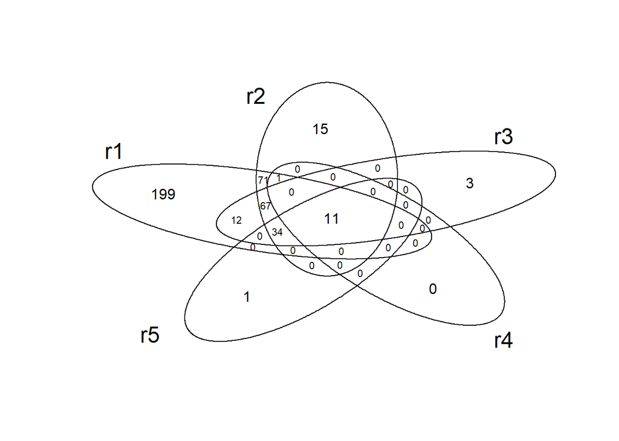

```r
# Initialize an empty list to store results
AllSelecVars <- list()

# Repeat the process five times
for (i in 1:5) {
    backwards_sel_rf <- varSelRF(xdata = t(train_data), Class = class_factor_train,
                                 ntree = 500, ntreeIterat = 200, vars.drop.frac = 0.037)
    AllSelecVars[[paste0("r", i)]] <- backwards_sel_rf$selected.vars
}
# Visualize the results with a Venn diagram
library(gplots)
venn_result <- venn(AllSelecVars)
plot(venn_result)
```

In the Venn Diagram you can see that each different variable selection run results in a different number of genes selected. However there are some that seem very consistent across runs- with a subset selected in every run.

```r
#We create a table of the different lists and make #it into a dataframe
table_of_runs<-data.frame(table(unlist(AllSelecVars)))
#Visualizing th genes that appears in all the runs
gene_list<- table_of_runs[table_of_runs[, 2] > 3, ]
gene_list
```

```
##            Var1 Freq
## 8         ALCAM    4
## 9         ALOX5    4
## 13        ANXA5    4
## 18       ARPC1B    4
## 28         BCAN    5
## 30        BCL7A    5
## 74         CTSC    4
## 77         DAB2    4
## 81         DGKI    4
## 104       EPHB1    4
## 105       EPHB4    4
## 111      FAM77C    4
## 115      FER1L3    5
## 124    FLJ21963    5
```

[output cut: 31 more lines]

Now that we have the above data we can always go back into building the model again with reduced variable list. We are always going to choose the simplest model with lowest number of parameters and high accuracy.